# Parkinson's Disease Classification with KNN

by Group 28 (Michael DeMarco, Philip Zhang, Chris Cai, Yuichi Ito)

[figure not shown]

**Figure 1** A screengrab from Praat, the acoustic analysis software used in collecting the data set

## Introduction

### Background

Parkinson’s disease (PD) is a degenerative disorder of the central nervous system (CNS) which severely impacts motor control. Parkinson’s has neither a cure nor a known cause. Speech, however, is widely known to play a significant role in the detection of PD. According to Sakar<sup>1</sup> , vocal disorder exists in 90% of patients at an early stage.

[1] Here's the link to the original [data set](http://archive.ics.uci.edu/ml/datasets/Parkinson%27s+Disease+Classification), and corresponding [paper](https://www.sciencedirect.com/science/article/abs/pii/S1568494618305799?via%3Dihub). Note that the paper used the data before a study with a similar goal but with very different predictor variables than the ones we select (to begin with) here.

### Question

To what extent can we use elements of speech sounds to predict whether or not a patient has Parkinson’s disease?

### Data set

Our data set is from [UCI’s Machine Learning repository](http://archive.ics.uci.edu/ml/datasets/Parkinson%27s+Disease+Classification). This data set contains numerous variables in speech sounds gathered by Sakar using the [Praat](http://www.fon.hum.uva.nl/praat/) acoustic analysis software. Each participant in the study was asked to repeat their pronunciations of the /a/ phoneme three times; each entry is thus associated with an ID parameter ranging from 0 to 251. We chose to focus on the following six predictor parameters:

[output not shown]

**Figure 2** Table describing each of the predictor's used in the original analysis

There’s a lot of complicated math associated with each of these parameters (including Fourier transforms, dense equations, etc.) so the interested reader is encouraged to reference Sakar directly.

## Preliminary exploratory data analysis in R

We'll now conduct a preliminary exploration of the data using R, to getter a better sense of what we'll be working with.

```r
# Reinstall packages (if needed)
install.packages("tidyverse")
install.packages("caret")
install.packages("repr")
install.packages("GGally")
# Fix for strange error message
install.packages("e1071")
```

```r
# Load in the necessary libraries
library(caret)
library(repr)
library(GGally)
library(tidyverse)
```

```r
# Make all of the following results reproducible
set.seed(28)
```

```r
# Reads the dataset from the web into R; the Drive URL is self-made
pd_data <- read_csv("https://drive.google.com/uc?export=download&id=1p9JuoTRM_-t56x7gptZU2TRNue8IHFHc", skip = 1)

#narrows down the dataset to the variables that we will use
baseline_data <- pd_data %>%
                select(id:meanHarmToNoiseHarmonicity, class)
```

```r
head(baseline_data)
```

A tibble: 6 × 24

| id <dbl> | gender <dbl> | PPE <dbl> | DFA <dbl> | RPDE <dbl> | numPulses <dbl> | numPeriodsPulses <dbl> | meanPeriodPulses <dbl> | stdDevPeriodPulses <dbl> | locPctJitter <dbl> | ⋯ | locShimmer <dbl> | locDbShimmer <dbl> | apq3Shimmer <dbl> | apq5Shimmer <dbl> | apq11Shimmer <dbl> | ddaShimmer <dbl> | meanAutoCorrHarmonicity <dbl> | meanNoiseToHarmHarmonicity <dbl> | meanHarmToNoiseHarmonicity <dbl> | class <dbl> |
| --- | --- | --- | --- | --- | --- | --- | --- | --- | --- | --- | --- | --- | --- | --- | --- | --- | --- | --- | --- | --- |
| 0 | 1 | 0.85247 | 0.71826 | 0.57227 | 240 | 239 | 0.008063530 | 0.000086800 | 0.00218 | ⋯ | 0.05883 | 0.517 | 0.03011 | 0.03496 | 0.04828 | 0.09034 | 0.970805 | 0.036223 | 18.995 | 1 |
| 0 | 1 | 0.76686 | 0.69481 | 0.53966 | 234 | 233 | 0.008258256 | 0.000073100 | 0.00195 | ⋯ | 0.05516 | 0.502 | 0.02320 | 0.03675 | 0.06195 | 0.06961 | 0.984322 | 0.017974 | 21.497 | 1 |
| 0 | 1 | 0.85083 | 0.67604 | 0.58982 | 232 | 231 | 0.008339590 | 0.000060400 | 0.00176 | ⋯ | 0.09902 | 0.897 | 0.05094 | 0.06497 | 0.07772 | 0.15282 | 0.974846 | 0.026313 | 17.651 | 1 |
| 1 | 0 | 0.41121 | 0.79672 | 0.59257 | 178 | 177 | 0.010857733 | 0.000182739 | 0.00419 | ⋯ | 0.05451 | 0.527 | 0.02395 | 0.02857 | 0.04462 | 0.07185 | 0.968343 | 0.042003 | 19.865 | 1 |
| 1 | 0 | 0.32790 | 0.79782 | 0.53028 | 236 | 235 | 0.008161574 | 0.002668863 | 0.00535 | ⋯ | 0.05610 | 0.497 | 0.02909 | 0.03327 | 0.05278 | 0.08728 | 0.975754 | 0.027139 | 19.557 | 1 |
| 1 | 0 | 0.50780 | 0.78744 | 0.65451 | 226 | 221 | 0.007631204 | 0.002696381 | 0.00783 | ⋯ | 0.07752 | 0.678 | 0.03805 | 0.04767 | 0.06451 | 0.11415 | 0.906720 | 0.137088 | 14.676 | 1 |

```r
# Averages the values of each subject's three trials so that each subject is represented by one row
project_data <- baseline_data %>%
                group_by(id) %>%
                summarize(PPE = mean(PPE),
                     DFA = mean(DFA),
                     RPDE = mean(RPDE),
                     meanPeriodPulses = mean(meanPeriodPulses),
                     locPctJitter = mean(locPctJitter),
                     locShimmer = mean(locShimmer),
                     # meanAutoCorrHarmonicity = mean(meanAutoCorrHarmonicity),--legacy from project proposal
                     class = mean(class)) %>%
                     mutate(class = as.factor(class)) %>%
                     mutate(has_pd = (class == 1))
head(project_data)
```

A tibble: 6 × 9

| id <dbl> | PPE <dbl> | DFA <dbl> | RPDE <dbl> | meanPeriodPulses <dbl> | locPctJitter <dbl> | locShimmer <dbl> | class <fct> | has_pd <lgl> |
| --- | --- | --- | --- | --- | --- | --- | --- | --- |
| 0 | 0.8233867 | 0.6963700 | 0.5672500 | 0.008220459 | 0.0019633333 | 0.07100333 | 1 | TRUE |
| 1 | 0.4156367 | 0.7939933 | 0.5924533 | 0.008883504 | 0.0057900000 | 0.06271000 | 1 | TRUE |
| 2 | 0.8019733 | 0.6199667 | 0.5205633 | 0.006040677 | 0.0022166667 | 0.04095333 | 1 | TRUE |
| 3 | 0.8287067 | 0.6260967 | 0.5371833 | 0.003913008 | 0.0007566667 | 0.04946667 | 1 | TRUE |
| 4 | 0.8312867 | 0.7793967 | 0.7267167 | 0.005621587 | 0.0035933333 | 0.15919333 | 1 | TRUE |
| 5 | 0.8225200 | 0.6220833 | 0.3576600 | 0.006814760 | 0.0009400000 | 0.03258333 | 1 | TRUE |

```r
# Determines which percentage of rows will be used in the training set and testing set (75%/25% split)
training_rows <- project_data %>%
                select(has_pd) %>%
                unlist() %>%
                createDataPartition(p = 0.75, list = FALSE)

# Splits the dataset into a training set and testing set
training_set <- project_data %>% slice(training_rows)
testing_set <- project_data %>% slice(-training_rows)

head(training_set)
```

A tibble: 6 × 9

| id <dbl> | PPE <dbl> | DFA <dbl> | RPDE <dbl> | meanPeriodPulses <dbl> | locPctJitter <dbl> | locShimmer <dbl> | class <fct> | has_pd <lgl> |
| --- | --- | --- | --- | --- | --- | --- | --- | --- |
| 1 | 0.4156367 | 0.7939933 | 0.5924533 | 0.008883504 | 0.005790000 | 0.06271000 | 1 | TRUE |
| 2 | 0.8019733 | 0.6199667 | 0.5205633 | 0.006040677 | 0.002216667 | 0.04095333 | 1 | TRUE |
| 4 | 0.8312867 | 0.7793967 | 0.7267167 | 0.005621587 | 0.003593333 | 0.15919333 | 1 | TRUE |
| 5 | 0.8225200 | 0.6220833 | 0.3576600 | 0.006814760 | 0.000940000 | 0.03258333 | 1 | TRUE |
| 6 | 0.8000333 | 0.6672833 | 0.3915767 | 0.006713578 | 0.001276667 | 0.05228667 | 1 | TRUE |
| 7 | 0.5291933 | 0.7748567 | 0.7126800 | 0.008029424 | 0.007440000 | 0.13953250 | 1 | TRUE |

A tibble: 2 × 2

| has_pd <lgl> | n <int> |
| --- | --- |
| FALSE | 48 |
| TRUE | 141 |

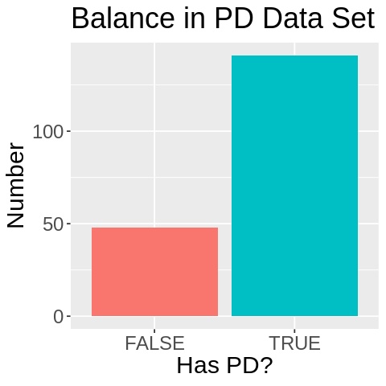

```r
# Reports the number of counts per class
class_counts <- training_set %>%
                    group_by(has_pd) %>%
                    summarize(n = n())
class_counts

options(repr.plot.width=4,repr.plot.height=4)

class_counts_plot <- ggplot(class_counts, aes(x = has_pd, y = n, fill = has_pd)) +
                   geom_bar(stat="identity") +
                   labs(x = 'Has PD?', y = 'Number', fill = "Has PD") +
                   ggtitle("Balance in PD Data Set") +
                   theme(text = element_text(size = 18), legend.position = "none")
class_counts_plot
```

```r
# Reports the means, maxes, and mins of each predictor variable used
predictor_max <- training_set %>%
                        select(PPE:locShimmer) %>%
                        map_df(~ max(., na.rm  = TRUE))
predictor_min <- training_set %>%
                        select(PPE:locShimmer) %>%
                        map_df(~ min(., na.rm  = TRUE))
predictor_mean <- training_set %>%
                        select(PPE:locShimmer) %>%
                        map_df(~ mean(., na.rm  = TRUE))

stats_merged <- rbind(predictor_max, predictor_min, predictor_mean)

stat <- c('max','mean','min')

stats_w_names <- data.frame(stat, stats_merged)

predictor_stats <- gather(stats_w_names,
                              key = variable,
                              value = value,
                              PPE:locShimmer)
predictor_stats
```

A data.frame: 18 × 3

| stat <fct> | variable <chr> | value <dbl> |
| --- | --- | --- |
| max | PPE | 0.851843333 |
| mean | PPE | 0.328186667 |
| min | PPE | 0.741362857 |
| max | DFA | 0.851113333 |
| mean | DFA | 0.555966667 |
| min | DFA | 0.698315467 |
| max | RPDE | 0.826476667 |
| mean | RPDE | 0.200946667 |
| min | RPDE | 0.492768607 |
| max | meanPeriodPulses | 0.010676097 |
| mean | meanPeriodPulses | 0.003319840 |
| min | meanPeriodPulses | 0.006393659 |
| max | locPctJitter | 0.015376667 |
| mean | locPctJitter | 0.000270000 |
| min | locPctJitter | 0.002353944 |
| max | locShimmer | 0.210770000 |
| mean | locShimmer | 0.018023333 |
| min | locShimmer | 0.068510132 |

[figure not shown]

```r
# Visualizes and compares the distributions of each of the predictor variables
plot_pairs <- training_set %>%
              select(PPE:locShimmer) %>%
              ggpairs(title = "PD speech predictor variable correlations")
plot_pairs
# plot_pairs

plot_pairs_by_class <- training_set %>%
                       ggpairs(.,
                               legend = 9,
                               columns = 2:8,
                               mapping = ggplot2::aes(colour=has_pd),
                               lower = list(continuous = wrap("smooth", alpha = 0.3, size=0.1)),
                               title = "PD speech predictor variable correlations by class") +
                       theme(legend.position = "bottom")
# plot_pairs_by_class
```

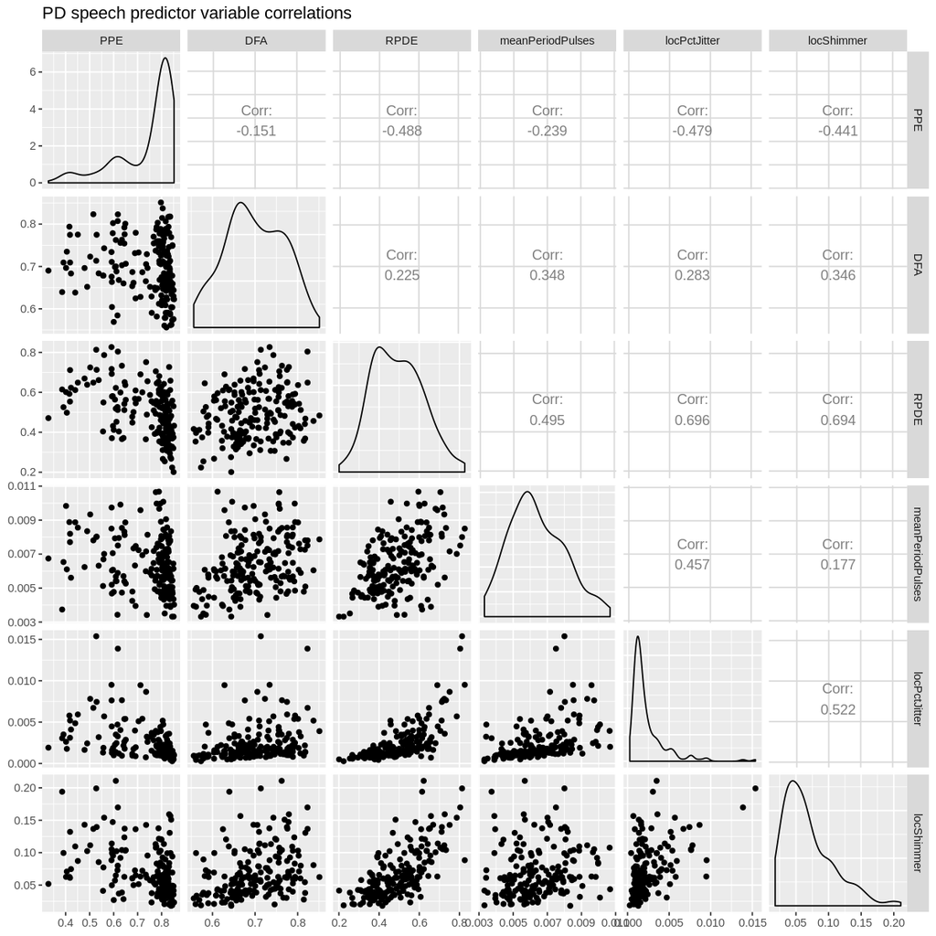

```r
options(repr.plot.width=10,repr.plot.height=10, repr.plot.pointsize=20)

plot_pairs
```

With this understanding, we can use a second plot, grouped and colored by `has_pd` to help us anticipate what the impact of these predictors will be. We can see that for every individual distribution, there is a marked difference between the red and blue groupings, which bodes well for our analysis. On average, the healthy patients (i.e., `has_pd == FALSE`) fall on the lower end of the spectrum for our predictors, apart from PPE, where they exhibit higher values on average. Though we won’t be able to visualize our final model directly (as it is in six dimensions), we can predict from those plots that the new patients which fall on the lower end for most of these distributions should be healthy. This also makes intuitive sense; Parkinson’s is a degenerative disease for the muscles, so patients would likely have higher, more rapid change in various speech variables, due to tremors.

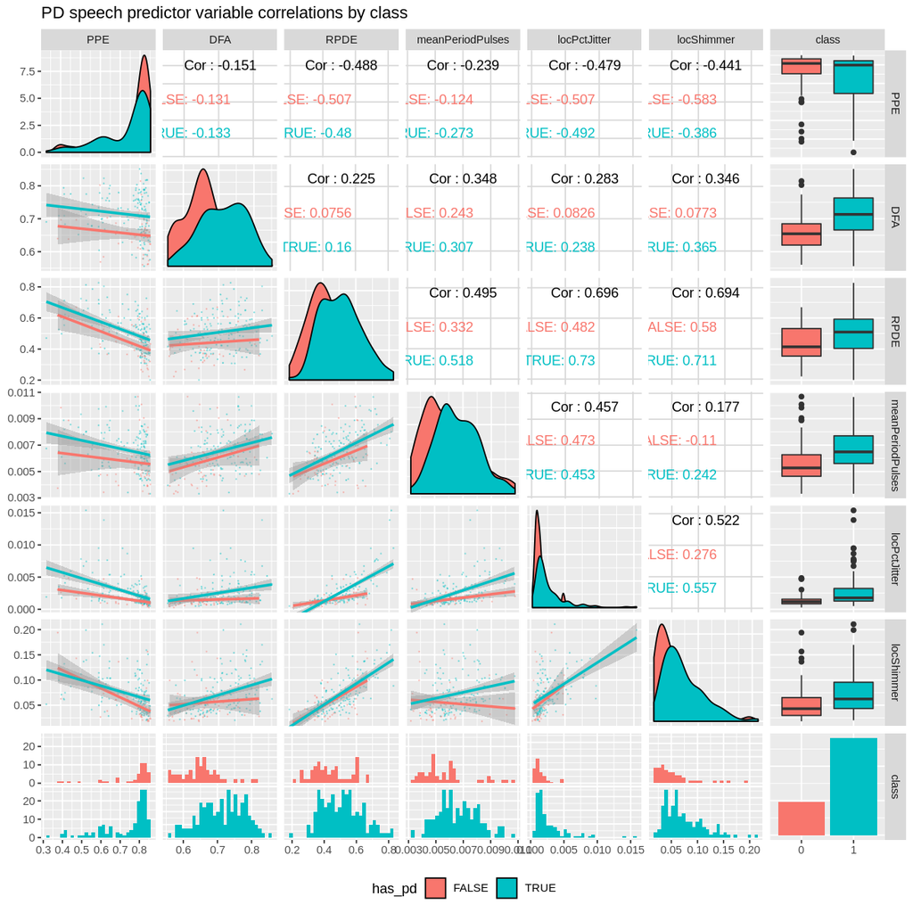

```r
plot_pairs_by_class
```

## Analysis

```r
# Scale the data set (pre-processing)
scale_transformer <- preProcess(training_set, method = c("center", "scale"))
training_set <- predict(scale_transformer, training_set)
test_set <- predict(scale_transformer, testing_set)
```

```r
X_train <- training_set %>%
  select(-class, -has_pd) %>%
  data.frame()
X_test <- testing_set %>%
  select(-class, -has_pd) %>%
  data.frame()

Y_train <- training_set %>%
  select(class) %>%
  unlist()
Y_test <- testing_set %>%
  select(class) %>%
  unlist()

head(X_train)
head(Y_train)
```

A data.frame: 6 × 7

|  | id <dbl> | PPE <dbl> | DFA <dbl> | RPDE <dbl> | meanPeriodPulses <dbl> | locPctJitter <dbl> | locShimmer <dbl> |
| --- | --- | --- | --- | --- | --- | --- | --- |
| 1 | -1.683733 | -2.6359943 | 1.4010383 | 0.7957175 | 1.5441097 | 1.58336090 | -0.1517248 |
| 2 | -1.669897 | 0.4905005 | -1.1472838 | 0.2218670 | -0.2189063 | -0.06325862 | -0.7208544 |
| 3 | -1.642224 | 0.7277236 | 1.1872951 | 1.8674532 | -0.4788107 | 0.57111998 | 2.3721690 |
| 4 | -1.628387 | 0.6567779 | -1.1162889 | -1.0784830 | 0.2611512 | -0.65155646 | -0.9398041 |
| 5 | -1.614551 | 0.4748007 | -0.4544124 | -0.8077486 | 0.1984019 | -0.49641786 | -0.4243873 |
| 6 | -1.600714 | -1.7170177 | 1.1208146 | 1.7554078 | 1.0144410 | 2.34369361 | 1.8578641 |

**class1**

1

**class2**

1

**class3**

1

**class4**

1

**class5**

1

**class6**

1

**Levels**:**

1. '0'

2. '1'

```r
train_control <- trainControl(method="cv", number = 10)
k <- data.frame(k = seq(from = 1, to = 101, by = 2))
knn_model_cv_10fold <- train(x = X_train, y = Y_train, method = "knn", tuneGrid = k, trControl = train_control)

knn_model_cv_10fold
```

```
k-Nearest Neighbors

189 samples
  7 predictor
  2 classes: '0', '1'

No pre-processing
Resampling: Cross-Validated (10 fold)
Summary of sample sizes: 170, 170, 170, 170, 170, 171, ...
Resampling results across tuning parameters:

  k    Accuracy   Kappa
    1  0.7463450   0.26887084
    3  0.7293860   0.16966497
    5  0.7568713   0.23181149
```

[output cut: 51 more lines]

```r
accuracies <- knn_model_cv_10fold$results
head(accuracies)
```

A data.frame: 6 × 5

|  | k <dbl> | Accuracy <dbl> | Kappa <dbl> | AccuracySD <dbl> | KappaSD <dbl> |
| --- | --- | --- | --- | --- | --- |
| 1 | 1 | 0.7463450 | 0.2688708 | 0.08445645 | 0.2466141 |
| 2 | 3 | 0.7293860 | 0.1696650 | 0.05158538 | 0.1909104 |
| 3 | 5 | 0.7568713 | 0.2318115 | 0.05562412 | 0.2155612 |
| 4 | 7 | 0.7513158 | 0.1898169 | 0.07440820 | 0.2437319 |
| 5 | 9 | 0.7621345 | 0.1817654 | 0.06555641 | 0.2504581 |
| 6 | 11 | 0.7404971 | 0.1091229 | 0.04697234 | 0.2144579 |

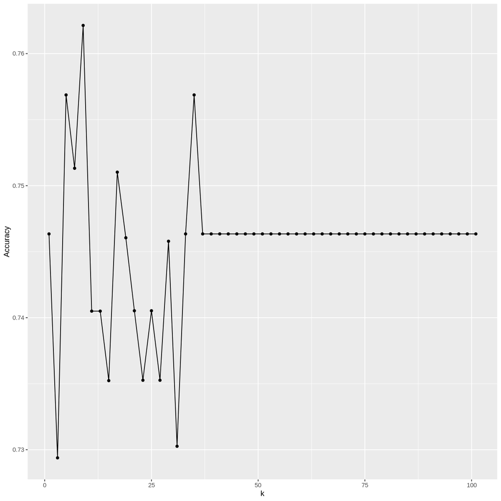

```r
options(repr.plot.height = 10, repr.plot.width = 10)

accuracy_vs_k <- ggplot(accuracies, aes(x = k, y = Accuracy)) +
  geom_point() +
  geom_line()
accuracy_vs_k
```

```r
k = data.frame(k = 5)

model_knn5 <- train(x = X_train, y = Y_train, method = "knn", tuneGrid = k)
model_knn5
```

```
k-Nearest Neighbors

189 samples
  7 predictor
  2 classes: '0', '1'

No pre-processing
Resampling: Bootstrapped (25 reps)
Summary of sample sizes: 189, 189, 189, 189, 189, 189, ...
Resampling results:

  Accuracy   Kappa
  0.7407884  0.2484329

Tuning parameter 'k' was held constant at a value of 5
```

```r
Y_test_predicted <- predict(object = model_knn5, X_test)
head(Y_test_predicted)
```

1. 1

2. 1

3. 1

4. 1

5. 1

6. 1

**Levels**:**

1. '0'

2. '1'

```r
model_quality <- confusionMatrix(data = Y_test_predicted, reference = Y_test)
model_quality
```

```
Confusion Matrix and Statistics

          Reference
Prediction  0  1
         0  0  1
         1 16 46

               Accuracy : 0.7302
                 95% CI : (0.6035, 0.8343)
    No Information Rate : 0.746
    P-Value [Acc > NIR] : 0.674739

                  Kappa : -0.0308

 Mcnemar's Test P-Value : 0.000685

            Sensitivity : 0.00000
            Specificity : 0.97872
         Pos Pred Value : 0.00000
         Neg Pred Value : 0.74194
             Prevalence : 0.25397
         Detection Rate : 0.00000
   Detection Prevalence : 0.01587
      Balanced Accuracy : 0.48936

       'Positive' Class : 0
```